# Certificate Applicant Dashboard 2018

```python
import numpy as np
import pandas as pd
%matplotlib inline
import matplotlib as mpl
import matplotlib.pyplot as plt
import seaborn as sns
from scipy.stats import pearsonr
import pandas.core.algorithms as algos
from pandas import Series
import scipy.stats.stats as stats
import re
import traceback
import string
from IPython.display import Image
```

## 1. Which segment of students would be more likely to pursue multiple professional education programs?

Analysis based on Question 5 (*Prior to this UW certificate program, have you ever considered, or enrolled in, any of the following professional and continuing education program formats? Select ALL that apply.*) in the Certificate Applicant Survey

```python
df1= pd.read_csv("C:\\Users\\gtang\\Desktop\\CA cleaned Q5.csv") #load data
```

```python
df1.dropna(subset=['Q5'],axis=0,inplace=True)  #drop empty data and check the size again
```

```python
df1.drop('Q5', axis=1, inplace=True)
```

```python
dfa=pd.DataFrame(df1['Segment'].value_counts())
dfa.rename(columns={'Segment':'Total'}, inplace=True)
```

```python
dfg=df1.groupby('Segment').sum()
```

```python
dfg=df1.groupby('Segment').sum()
dfa=pd.concat([dfa, dfg], axis=1,sort=True)
```

```python
dfa.rename(columns={'Q5c':'Y'}, inplace=True)
#dfa.assign(N = dfa.Total + dfa.Y)
dfa['N']=dfa['Total']-dfa['Y']
```

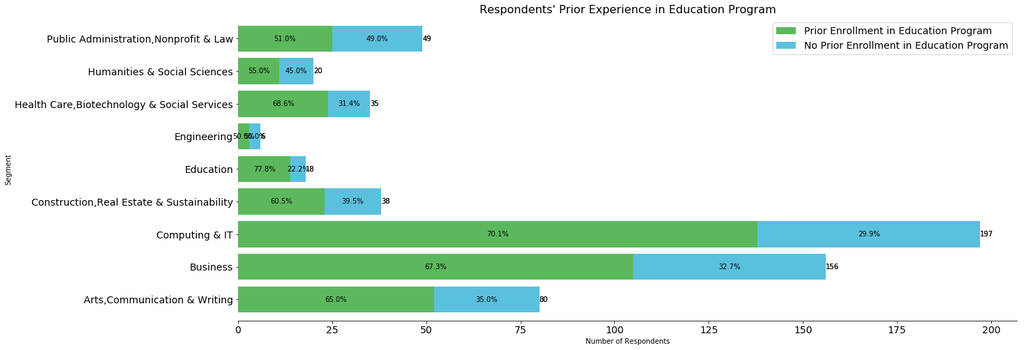

```python
fig = plt.figure(frameon=False)
ax=dfa.plot.barh(y=['Y','N'],stacked=True,figsize=(20,8),color=['#5cb85c','#5bc0de'],width=0.8,fontsize=14)
ax.set_title("Respondents' Prior Experience in Education Program",fontsize=16)
ax.legend(['Prior Enrollment in Education Program','No Prior Enrollment in Education Program'],fontsize=14)
ax.spines['top'].set_visible(False)
ax.spines['right'].set_visible(False)
ax.spines['left'].set_visible(False)
ax.set_ylabel('Segment')
ax.set_xlabel('Number of Respondents')
dfa_T=dfa['Total']
df_rel = dfa[dfa.columns[1:]].div(dfa_T, 0)*100
for n in df_rel:
    for i, (cs, ab, pc, tot) in enumerate(zip(dfa.iloc[:, 1:].cumsum(1)[n], dfa[n], df_rel[n], dfa_T)):
        plt.text(tot, i, str(tot), va='center')
        plt.text(cs - ab/2, i, str(np.round(pc, 1)) + '%', va='center', ha='center')
```

As we can tell from the graph above, before considering or applying to UW's professional education programs, most of the respondents already pursued other programs. This shows two aspects: **Most respondents might not think that one program is enough to achieve their goals, and UW's education programs are more comprehensive than or is a complement to the ones that they did before. The programs in Education, Computing& IT and Busines fields might attract more returning students if there are other programs at UW that satify their needs.**

## 2. Is there any correlation between program length and the number of applicants and prospects?

Analysis based on Question 12 (*In terms of program length, which of the following options best fit your professional development and/or continuing education needs given your existing career and life demands?*) in the Certificate Applicant Survey

```python
df2= pd.read_csv("C:\\Users\\gtang\\Desktop\\CA cleaned Q12.csv",error_bad_lines=False) #load data
```

```python
df2.dropna(subset=['Q12'],axis=0,inplace=True)
df2 = df2[df2.Q12 != 8]
```

```python
df2a=pd.DataFrame(df2['Q12'].value_counts())
df2a = df2a.reset_index()
df2a.rename(columns={'index':'Length','Q12':'Number'}, inplace=True)
```

```python
coef,pv=pearsonr(df2a['Length'],df2a['Number'])
print('The correlation coefficient is', coef)
print('The p-value is',pv)
```

```
The correlation coefficient is 0.6196560636183391
The p-value is 0.1377666585490872
```

According to our statistical analysis **there is no significant relationship between the length of the program and the number of applicants and prospects.**

## 3. Is there any difference between prospects' and applicants' prospectives? Why do the prospects never apply?

### Exploratory Data Analysis(Histogram)

Analysis based on Question 6 (*What are your top three considerations when choosing a professional and continuing education program?*) in the Certificate Applicant Survey

```python
df3= pd.read_csv("C:\\Users\\gtang\\Desktop\\combine3t.csv")
```

```python
df3_c=df3.set_index(['ID','features','goals','cost','type']).stack().str.split(',', expand=True).stack().unstack(-2).reset_index(-1, drop=True).reset_index()
```

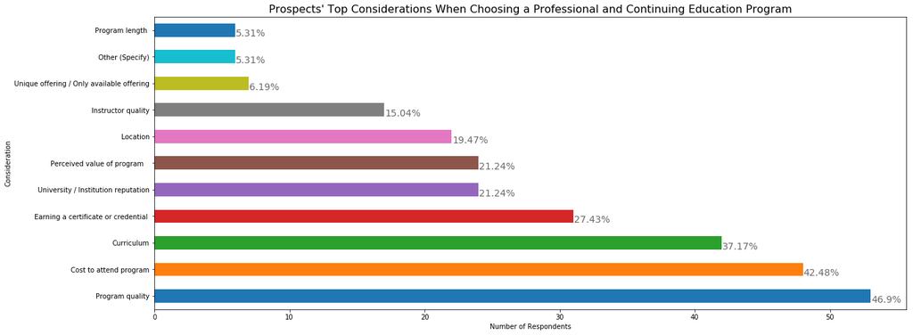

```python
ax=df3_c[(df3_c['type']=='Prospect')].con.value_counts().plot.barh(figsize=(20,8))
ax.set_title("Prospects' Top Considerations When Choosing a Professional and Continuing Education Program",fontsize=16)
ax.set_xlabel('Number of Respondents')
ax.set_ylabel('Consideration')
for i in ax.patches:
    # get_width pulls left or right; get_y pushes up or down
   ax.text(i.get_width()+.05, i.get_y()+.01, \
            str((round(i.get_width()/113*100,2)))+'%', fontsize=14, color='dimgrey')
```

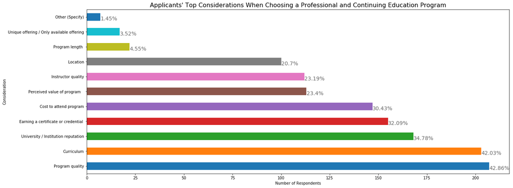

```python
ax=df3_c[(df3_c['type']=='Applicant')].con.value_counts().plot.barh(figsize=(20,8))
ax.set_title("Applicants' Top Considerations When Choosing a Professional and Continuing Education Program",fontsize=16)
ax.set_xlabel('Number of Respondents')
ax.set_ylabel('Consideration')
for i in ax.patches:
    # get_width pulls left or right; get_y pushes up or down
   ax.text(i.get_width()+.05, i.get_y()+.01, \
            str((round(i.get_width()/483*100,2)))+'%', fontsize=14, color='dimgrey')
```

**When choosing a program, applicants' and prospects' major considerations are quite similar. They both think highly of Program Quality and Curriculum. However, most applicants also consider University Reputation as one of their top three while most prospects are more concerned about Cost to Attend Program.**

Analysis based on Question 10 (*Among all professional and continuing education programs you’ve considered, which of the following features of these programs appeal to you the most? Select ALL that apply.*) in the Certificate Applicant Survey

```python
df3_c=df3.set_index(['ID','con','goals','cost','type']).stack().str.split(',', expand=True).stack().unstack(-2).reset_index(-1, drop=True).reset_index()
```

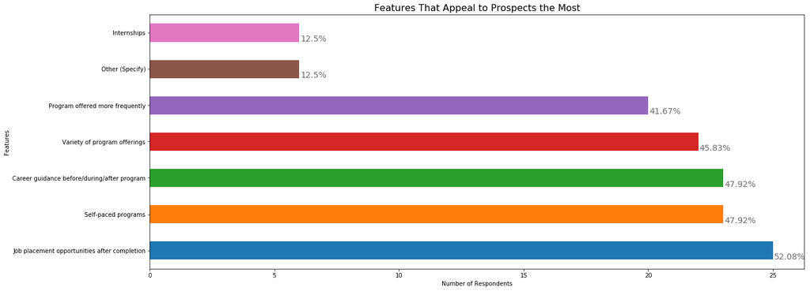

```python
ax=df3_c[(df3_c['type']=='Prospect')].features.value_counts().plot.barh(figsize=(20,8))
ax.set_title("Features That Appeal to Prospects the Most",fontsize=16)
ax.set_xlabel('Number of Respondents')
ax.set_ylabel('Features')
for i in ax.patches:
    # get_width pulls left or right; get_y pushes up or down
   ax.text(i.get_width()+.05, i.get_y()+.01, \
            str((round(i.get_width()/48*100,2)))+'%', fontsize=14, color='dimgrey')
```

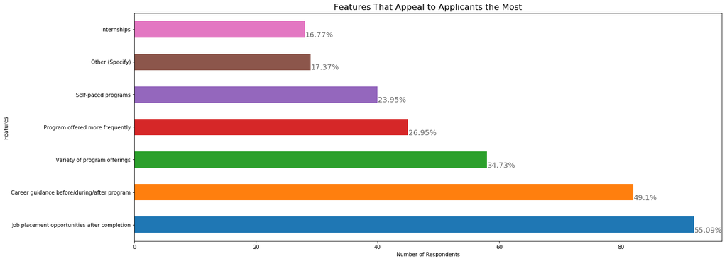

```python
ax=df3_c[(df3_c['type']=='Applicant')].features.value_counts().plot.barh(figsize=(20,8))
ax.set_title("Features That Appeal to Applicants the Most",fontsize=16)
ax.set_xlabel('Number of Respondents')
ax.set_ylabel('Features')
for i in ax.patches:
    # get_width pulls left or right; get_y pushes up or down
   ax.text(i.get_width()+.05, i.get_y()+.01, \
            str((round(i.get_width()/167*100,2)))+'%', fontsize=14, color='dimgrey')
```

**Both applicants and prospects are career-driven. They found job placement opportunities after completion and career guidance most appealing. However, there is a huge proportion of prospects prefer self-paced programs. Only 25 of the 361 certificate programs are self-paced/online. Lack of program flexibility can be one of the major reasons why prospects have not apply to the programs.**

Analysis based on Question 11 (*Which of the following would make it easier to find the right program or course to achieve your professional and continuing education goals? Select ALL that apply.* ) in the Certificate Applicant Survey

```python
df3_c=df3.set_index(['ID','con','features','cost','type']).stack().str.split(',', expand=True).stack().unstack(-2).reset_index(-1, drop=True).reset_index()
```

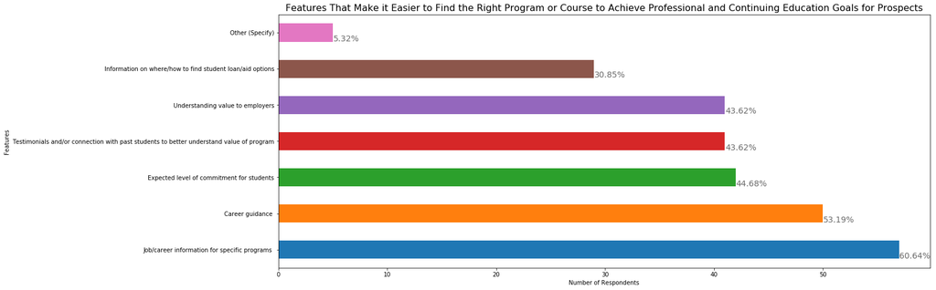

```python
ax=df3_c[(df3_c['type']=='Prospect')].goals.value_counts().plot.barh(figsize=(20,8))
ax.set_title("Features That Make it Easier to Find the Right Program or Course to Achieve Professional and Continuing Education Goals for Prospects",fontsize=16)
ax.set_xlabel('Number of Respondents')
ax.set_ylabel('Features')
for i in ax.patches:
    # get_width pulls left or right; get_y pushes up or down
   ax.text(i.get_width()+.05, i.get_y()+.01, \
            str((round(i.get_width()/94*100,2)))+'%', fontsize=14, color='dimgrey')
```

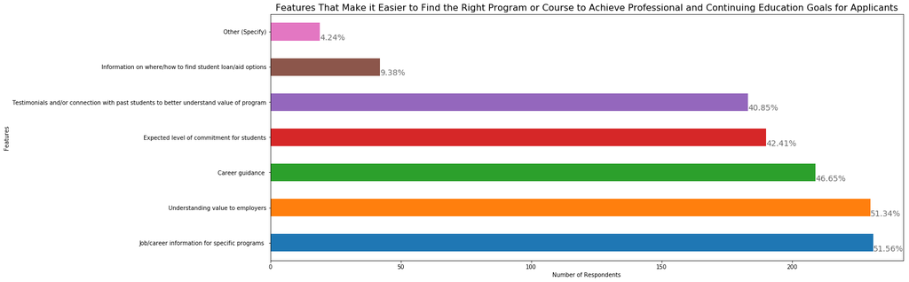

```python
ax=df3_c[(df3_c['type']=='Applicant')].goals.value_counts().plot.barh(figsize=(20,8))
ax.set_title("Features That Make it Easier to Find the Right Program or Course to Achieve Professional and Continuing Education Goals for Applicants",fontsize=16)
ax.set_xlabel('Number of Respondents')
ax.set_ylabel('Features')
for i in ax.patches:
    # get_width pulls left or right; get_y pushes up or down
   ax.text(i.get_width()+.05, i.get_y()+.01, \
            str((round(i.get_width()/448*100,2)))+'%', fontsize=14, color='dimgrey')
```

**Applicants and prospects have similar desired features that make it easier to find the right programs: Job/career information to specific programs, Understanding value to employers, Career guidance, Expected level of commitment for students, Testimonials and/or connection with past students to better understand value of program are the most popular ones.**

Analysis based on Question 15 (*How does the cost of this UW program compare to your expectations?*) in the Certificate Applicant Survey

```python
df3_c=df3.set_index(['ID','con','features','goals','type']).stack().str.split(',', expand=True).stack().unstack(-2).reset_index(-1, drop=True).reset_index()
```

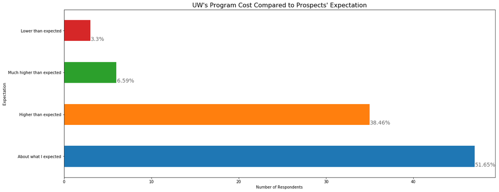

```python
ax=df3_c[(df3_c['type']=='Prospect')].cost.value_counts().plot.barh(figsize=(20,8))
ax.set_title("UW's Program Cost Compared to Prospects' Expectation",fontsize=16)
ax.set_xlabel('Number of Respondents')
ax.set_ylabel('Expectation')
for i in ax.patches:
    # get_width pulls left or right; get_y pushes up or down
   ax.text(i.get_width()+.05, i.get_y()+.01, \
            str((round(i.get_width()/91*100,2)))+'%', fontsize=14, color='dimgrey')
```

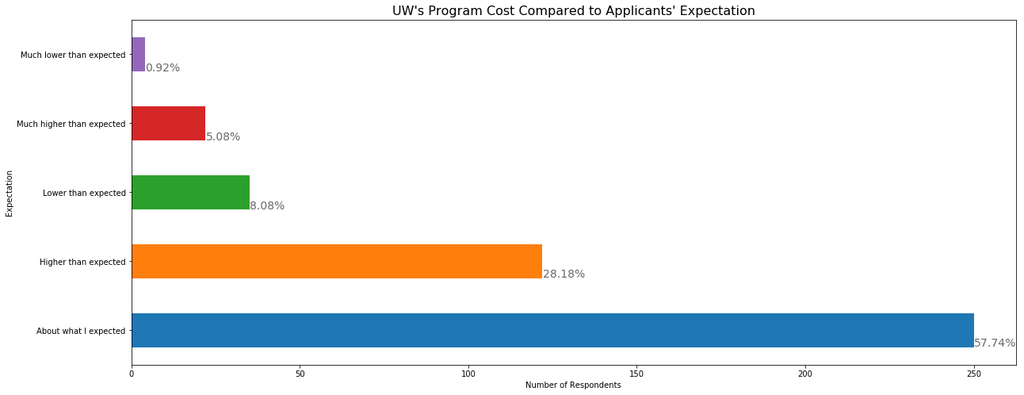

```python
ax=df3_c[(df3_c['type']=='Applicant')].cost.value_counts().plot.barh(figsize=(20,8))
ax.set_title("UW's Program Cost Compared to Applicants' Expectation",fontsize=16)
ax.set_xlabel('Number of Respondents')
ax.set_ylabel('Expectation')
for i in ax.patches:
    # get_width pulls left or right; get_y pushes up or down
   ax.text(i.get_width()+.05, i.get_y()+.01, \
            str((round(i.get_width()/433*100,2)))+'%', fontsize=14, color='dimgrey')
```

**Cost is a major concern for both applicants and prospects. The cost of the program is about what most applicants and prospects expect. However, interestingly, no prospect thinks the program cost is much lower than expected. The percentage of prospect who think the programs are overpriced is more than 10 percent higher than the percentage of applicants with the same thought. High cost could be another factor that explains those prospects who have not applied for the programs.**

### Feature selection (Weight of evidence and Information Value) & Logistic Regression

Analysis based on Question 6 (*What are your top three considerations when choosing a professional and continuing education program?*), Question 10 (*Among all professional and continuing education programs you’ve considered, which of the following features of these programs appeal to you the most? Select ALL that apply.*), Question 11 (*Which of the following would make it easier to find the right program or course to achieve your professional and continuing education goals? Select ALL that apply.*), Question 15 (*How does the cost of this UW program compare to your expectations?*) in the Certificate Applicant Survey

In machine learning, **feature selection** is the process of choosing variables that are useful in predicting the response (Y).**Logistic regression** is a statistical model that in its basic form uses a logistic function to model a binary dependent variable, in our case, which is whether a respondent applied to the program or not ('Prospect' is 0, and 'Applicant' is 1).

```python
df3a= pd.read_csv("C:\\Users\\gtang\\Desktop\\combine3.csv")
df3a.dropna(subset=['con','features','goals','cost'],axis=0,inplace=True)
```

```python
df_con=df3a['con'].str.join(sep=',').str.get_dummies(sep=',')
df_con.drop('0', 1,inplace=True)
df_con.columns = ['con1', 'con2','con3','con4','con5','con7','con8','con9']
```

```python
df_f=df3a['features'].str.join(sep=',').str.get_dummies(sep=',')
df_f.columns = ['f1', 'f2','f3','f4','f5','f6','f7']
```

```python
df_g=df3a['goals'].str.join(sep=',').str.get_dummies(sep=',')
df_g.columns = ['g1', 'g2','g3','g4','g5','g6','g7']
```

```python
df_cos=pd.get_dummies(df3a['cost'])
df_cos.columns = ['cost1', 'cost2','cost3','cost4','cost5']
```

```python
df3a=pd.concat([df3a, df_con,df_f,df_g,df_cos], axis=1,sort=False)
```

```python
df3a.type.loc[df3a.type == 'Prospect'] = 0
df3a.type.loc[df3a.type == 'Applicant'] = 1
```

```python
df3a.drop(['ID','con','features','goals','cost'], 1,inplace=True)
```

```python
max_bin = 20
force_bin = 3

# define a binning function
def mono_bin(Y, X, n = max_bin):

    df1 = pd.DataFrame({"X": X, "Y": Y})
    justmiss = df1[['X','Y']][df1.X.isnull()]
    notmiss = df1[['X','Y']][df1.X.notnull()]
    r = 0
    while np.abs(r) < 1:
        try:
            d1 = pd.DataFrame({"X": notmiss.X, "Y": notmiss.Y, "Bucket": pd.qcut(notmiss.X, n)})
            d2 = d1.groupby('Bucket', as_index=True)
            r, p = stats.spearmanr(d2.mean().X, d2.mean().Y)
            n = n - 1
        except Exception as e:
            n = n - 1

    if len(d2) == 1:
        n = force_bin
        bins = algos.quantile(notmiss.X, np.linspace(0, 1, n))
        if len(np.unique(bins)) == 2:
            bins = np.insert(bins, 0, 1)
            bins[1] = bins[1]-(bins[1]/2)
        d1 = pd.DataFrame({"X": notmiss.X, "Y": notmiss.Y, "Bucket": pd.cut(notmiss.X, np.unique(bins),include_lowest=True)})
        d2 = d1.groupby('Bucket', as_index=True)

    d3 = pd.DataFrame({},index=[])
    d3["MIN_VALUE"] = d2.min().X
    d3["MAX_VALUE"] = d2.max().X
    d3["COUNT"] = d2.count().Y
    d3["EVENT"] = d2.sum().Y
    d3["NONEVENT"] = d2.count().Y - d2.sum().Y
    d3=d3.reset_index(drop=True)

    if len(justmiss.index) > 0:
        d4 = pd.DataFrame({'MIN_VALUE':np.nan},index=[0])
        d4["MAX_VALUE"] = np.nan
        d4["COUNT"] = justmiss.count().Y
        d4["EVENT"] = justmiss.sum().Y
        d4["NONEVENT"] = justmiss.count().Y - justmiss.sum().Y
        d3 = d3.append(d4,ignore_index=True)

    d3["EVENT_RATE"] = d3.EVENT/d3.COUNT
    d3["NON_EVENT_RATE"] = d3.NONEVENT/d3.COUNT
    d3["DIST_EVENT"] = d3.EVENT/d3.sum().EVENT
    d3["DIST_NON_EVENT"] = d3.NONEVENT/d3.sum().NONEVENT
    d3["WOE"] = np.log(d3.DIST_EVENT/d3.DIST_NON_EVENT)
    d3["IV"] = (d3.DIST_EVENT-d3.DIST_NON_EVENT)*np.log(d3.DIST_EVENT/d3.DIST_NON_EVENT)
    d3["VAR_NAME"] = "VAR"
    d3 = d3[['VAR_NAME','MIN_VALUE', 'MAX_VALUE', 'COUNT', 'EVENT', 'EVENT_RATE', 'NONEVENT', 'NON_EVENT_RATE', 'DIST_EVENT','DIST_NON_EVENT','WOE', 'IV']]
    d3 = d3.replace([np.inf, -np.inf], 0)
    d3.IV = d3.IV.sum()

    return(d3)

def char_bin(Y, X):

    df1 = pd.DataFrame({"X": X, "Y": Y})
    justmiss = df1[['X','Y']][df1.X.isnull()]
    notmiss = df1[['X','Y']][df1.X.notnull()]
    df2 = notmiss.groupby('X',as_index=True)

    d3 = pd.DataFrame({},index=[])
    d3["COUNT"] = df2.count().Y
    d3["MIN_VALUE"] = df2.sum().Y.index
    d3["MAX_VALUE"] = d3["MIN_VALUE"]
    d3["EVENT"] = df2.sum().Y
    d3["NONEVENT"] = df2.count().Y - df2.sum().Y

    if len(justmiss.index) > 0:
        d4 = pd.DataFrame({'MIN_VALUE':np.nan},index=[0])
        d4["MAX_VALUE"] = np.nan
        d4["COUNT"] = justmiss.count().Y
        d4["EVENT"] = justmiss.sum().Y
        d4["NONEVENT"] = justmiss.count().Y - justmiss.sum().Y
        d3 = d3.append(d4,ignore_index=True)

    d3["EVENT_RATE"] = d3.EVENT/d3.COUNT
    d3["NON_EVENT_RATE"] = d3.NONEVENT/d3.COUNT
    d3["DIST_EVENT"] = d3.EVENT/d3.sum().EVENT
    d3["DIST_NON_EVENT"] = d3.NONEVENT/d3.sum().NONEVENT
    d3["WOE"] = np.log(d3.DIST_EVENT/d3.DIST_NON_EVENT)
    d3["IV"] = (d3.DIST_EVENT-d3.DIST_NON_EVENT)*np.log(d3.DIST_EVENT/d3.DIST_NON_EVENT)
    d3["VAR_NAME"] = "VAR"
    d3 = d3[['VAR_NAME','MIN_VALUE', 'MAX_VALUE', 'COUNT', 'EVENT', 'EVENT_RATE', 'NONEVENT', 'NON_EVENT_RATE', 'DIST_EVENT','DIST_NON_EVENT','WOE', 'IV']]
    d3 = d3.replace([np.inf, -np.inf], 0)
    d3.IV = d3.IV.sum()
    d3 = d3.reset_index(drop=True)

    return(d3)

def data_vars(df1, target):

    stack = traceback.extract_stack()
    filename, lineno, function_name, code = stack[-2]
    vars_name = re.compile(r'\((.*?)\).*$').search(code).groups()[0]
    final = (re.findall(r"[\w']+", vars_name))[-1]

    x = df1.dtypes.index
    count = -1

    for i in x:
        if i.upper() not in (final.upper()):
            if np.issubdtype(df1[i], np.number) and len(Series.unique(df1[i])) > 2:
                conv = mono_bin(target, df1[i])
                conv["VAR_NAME"] = i
                count = count + 1
            else:
                conv = char_bin(target, df1[i])
                conv["VAR_NAME"] = i
                count = count + 1

            if count == 0:
                iv_df = conv
            else:
                iv_df = iv_df.append(conv,ignore_index=True)

    iv = pd.DataFrame({'IV':iv_df.groupby('VAR_NAME').IV.max()})
    iv = iv.reset_index()
    return(iv_df,iv)
```

```python
final_iv, IV = data_vars(df3a , df3a.type)
```

```python
IV.sort_values('IV',ascending = False)
```

|  | VAR_NAME | IV |
| --- | --- | --- |
| 24 | g5 | 0.393169 |
| 16 | f4 | 0.360683 |
| 11 | cost4 | 0.198890 |
| 10 | cost3 | 0.118759 |
| 1 | con2 | 0.081533 |
| 22 | g3 | 0.081201 |
| 4 | con5 | 0.078625 |
| 17 | f5 | 0.075387 |
| 23 | g4 | 0.074196 |
| 7 | con9 | 0.068066 |
| 5 | con7 | 0.047199 |
| 2 | con3 | 0.033000 |
| 20 | g1 | 0.029898 |
| 25 | g6 | 0.028875 |
| 21 | g2 | 0.026244 |
| 3 | con4 | 0.026242 |
| 9 | cost2 | 0.025594 |
| 18 | f6 | 0.020737 |
| 19 | f7 | 0.019172 |
| 0 | con1 | 0.005847 |
| 15 | f3 | 0.004316 |
| 12 | cost5 | 0.003023 |
| 6 | con8 | 0.002821 |
| 13 | f1 | 0.002041 |
| 26 | g7 | 0.001275 |
| 14 | f2 | 0.000095 |
| 8 | cost1 | 0.000042 |

The Information Value(IV) can be used to judge how important a given categorical variable is in explaining the binary Y variable. It goes well with logistic regression.

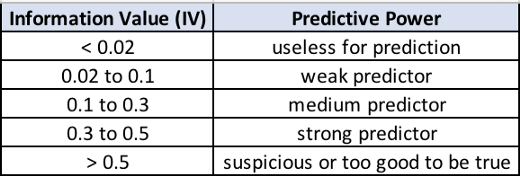

```python
from PIL import Image
path = "C:\\Users\\gtang\\Desktop\\IV.png"
display(Image.open(path))
```

Based on the result of Information Value of each factor, the selection of following factors have a critical impact on respondents' decision on whether to apply for the program:  
**(g5)Information on where/how to find student loan/aid options** in 'Which of the following would make it easier to find the right program or course to achieve your professional and continuing education goals? Select ALL that apply.'  
**(f4)Self-paced programs** in 'Among all professional and continuing education programs you’ve considered, which of the following features of these programs appeal to you the most? Select ALL that apply.'  
**(cost4)Higher than expected** in 'How does the cost of this UW program compare to your expectations?'

Then we run the logistic regression.

```python
X = np.asarray(df3a[['g5','f4','cost4']])
y = np.asarray(df3a['type'])
```

```python
from sklearn import preprocessing
X = preprocessing.StandardScaler().fit(X).transform(X)
```

```python
from sklearn.model_selection import train_test_split
X_train, X_test, y_train, y_test = train_test_split( X, y, test_size=0.2, random_state=4)
```

```python
from sklearn.linear_model import LogisticRegression
from sklearn.metrics import confusion_matrix
logreg = LogisticRegression()
logreg.fit(X_train,y_train)
y_pred=logreg.predict(X_test)
```

```python
yhat = logreg.predict(X_test)
```

```python
yhat_prob = logreg.predict_proba(X_test)
```

```python
from sklearn.metrics import classification_report, confusion_matrix
import itertools
def plot_confusion_matrix(cm, classes,
                          normalize=False,
                          title='Confusion matrix',
                          cmap=plt.cm.Blues):
    """
    This function prints and plots the confusion matrix.
    Normalization can be applied by setting `normalize=True`.
    """
    if normalize:
        cm = cm.astype('float') / cm.sum(axis=1)[:, np.newaxis]
        print("Normalized confusion matrix")
    else:
        print('Confusion matrix, without normalization')

    print(cm)

    plt.imshow(cm, interpolation='nearest', cmap=cmap)
    plt.title(title)
    plt.colorbar()
    tick_marks = np.arange(len(classes))
    plt.xticks(tick_marks, classes, rotation=45)
    plt.yticks(tick_marks, classes)

    fmt = '.2f' if normalize else 'd'
    thresh = cm.max() / 2.
    for i, j in itertools.product(range(cm.shape[0]), range(cm.shape[1])):
        plt.text(j, i, format(cm[i, j], fmt),
                 horizontalalignment="center",
                 color="white" if cm[i, j] > thresh else "black")

    plt.tight_layout()
    plt.ylabel('True label')
    plt.xlabel('Predicted label')
print(confusion_matrix(y_test, yhat, labels=[1,0]))
```

```
[[28  0]
 [ 8  3]]
```

We split the data into the training set and the testing set. Confusion matrix is a nice way to visualize how accurate our model is based on the predicted result of the testing set and its real value.

```
Confusion matrix, without normalization
[[28  0]
 [ 8  3]]
```

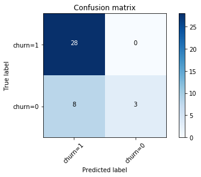

```python
# Compute confusion matrix
cnf_matrix = confusion_matrix(y_test, yhat, labels=[1,0])
np.set_printoptions(precision=2)


# Plot non-normalized confusion matrix
plt.figure()
plot_confusion_matrix(cnf_matrix, classes=['churn=1','churn=0'],normalize= False,  title='Confusion matrix')
```

```python
print (classification_report(y_test, yhat))
```

```
             precision    recall  f1-score   support

          0       1.00      0.27      0.43        11
          1       0.78      1.00      0.88        28

avg / total       0.84      0.79      0.75        39
```

```python
from sklearn.metrics import accuracy_score
print("Accuracy:", accuracy_score(y_test, yhat))
```

```
Accuracy: 0.7948717948717948
```

As you can see, the model did a good job in predicting an applicant with 79% of the accuracy based on the if the three major factors are selected:  
**(g5)Information on where/how to find student loan/aid options** in 'Which of the following would make it easier to find the right program or course to achieve your professional and continuing education goals? Select ALL that apply.'  
**(f4)Self-paced programs** in 'Among all professional and continuing education programs you’ve considered, which of the following features of these programs appeal to you the most? Select ALL that apply.'  
**(cost4)Higher than expected** in 'How does the cost of this UW program compare to your expectations?'

**Combining these two section of analysis, we can conclude that there are three possible reasons why a prospect has not become an applicant:**

1. Prospects expect to find information on where/how to find student loan/aid options on program webpages. This can make it easier for them to find the right program.
2. Prospects prefer self-paced programs, but we only offer a limited number of self-paced ones.
3. Prospects think the cost of the program is higher than their expectation.

## 4. Is the pricing of each program reasonable?

Analysis based on Question 15 (*How does the cost of this UW program compare to your expectations?*) in the Certificate Applicant Survey

```python
df4= pd.read_csv("C:\\Users\\gtang\\Desktop\\CA cleaned Q15.csv")
```

```python
df4.dropna(subset=['Cost Expectation'],axis=0,inplace=True)
```

```python
df4g=df4.groupby('Program').mean()
```

```python
dfop=df4g[df4g['Cost Expectation']>3]
print(dfop.index)
```

```
Index(['Accounting', 'Aircraft Composite Structural Analysis and Design',
       'Applied Animal Behavior', 'Applied Biostatistics', 'Basic Bioscience',
       'Big Data Technologies', 'Biomedical Regulatory Affairs',
       'Business Administration', 'Business Analysis', 'Clinical Trials',
       'Cloud Application Development on AWS', 'Commercial Real Estate',
       'Computational Finance', 'Construction Management',
       'Contract Management & Negotiation', 'Cybersecurity',
       'Data Analytics: Techniques for Decision Making', 'Data Science',
       'Data Visualization', 'Digital Marketing',
       'E-Learning Instructional Design', 'Editing', 'Engineering Leadership',
       'Ethical Hacking', 'Facility Management',
       'Front-End Development with HTML, CSS & JavaScript',
       'Fundraising Management', 'Geographic Information Systems',
       'Gerontology', 'Global Business', 'Global Business First Quarter',
       'Global Business Third Quarter',
       'Graduate Certificate in Palliative Care', 'Guardianship',
       'Health Economics and Outcomes Research', 'Human Resources Management',
       'Information Security and Risk Management', 'Java Programming',
       'JavaScript', 'Localization: Customizing Software for the World',
       'Machine Learning', 'Museum Studies', 'Natural Science Illustration',
       'Nonprofit Management', 'Paralegal Studies', 'Program Management',
       'Project Management', 'Python Programming',
       'Software Product Management',
       'Statistical Analysis with R Programming',
       'Storytelling and Content Strategy', 'User-Centered Design',
       'Wetland Science and Management', 'Women's Entrepreneurial Leadership'],
      dtype='object', name='Program')
```

**These are the programs which our respondents think are overpriced:**  
'Accounting', 'Aircraft Composite Structural Analysis and Design','Applied Animal Behavior', 'Applied Biostatistics',  
'Basic Bioscience','Big Data Technologies', 'Biomedical Regulatory Affairs','Business Administration', 'Business Analysis',  
'Clinical Trials', 'Cloud Application Development on AWS', 'Commercial Real Estate','Computational Finance', 'Construction Management','Contract Management & Negotiation', 'Cybersecurity',  
'Data Analytics: Techniques for Decision Making', 'Data Science', 'Data Visualization', 'Digital Marketing',  
'E-Learning Instructional Design', 'Editing', 'Engineering Leadership','Ethical Hacking',  
'Facility Management','Front-End Development with HTML, CSS & JavaScript','Fundraising Management',  
'Geographic Information Systems', 'Gerontology', 'Global Business', 'Global Business First Quarter','Global Business Third Quarter', 'Graduate Certificate in Palliative Care', 'Guardianship',  
'Health Economics and Outcomes Research', 'Human Resources Management',  
'Information Security and Risk Management',  
'Java Programming','JavaScript',  
'Localization: Customizing Software for the World',  
'Machine Learning', 'Museum Studies',  
'Natural Science Illustration', 'Nonprofit Management',  
'Paralegal Studies', 'Program Management', 'Project Management', 'Python Programming',  
'Software Product Management', 'Statistical Analysis with R Programming', 'Storytelling and Content Strategy',  
'User-Centered Design',  
'Wetland Science and Management', 'Women's Entrepreneurial Leadership'

```python
dfup=df4g[df4g['Cost Expectation']<3]
print(dfup.index)
```

```
Index(['Audio Production', 'Game Design', 'Private Investigation',
       'Professional Technical Writing', 'Strategic Marketing',
       'UX and Visual Interface Design'],
      dtype='object', name='Program')
```

**These are the programs which our respondents think are underpriced:**  
'Audio Production', 'Game Design', 'Private Investigation', 'Professional Technical Writing', 'Strategic Marketing', 'UX and Visual Interface Design'